# Analyses of GSE138058

## Volcano Plot with Gene Length

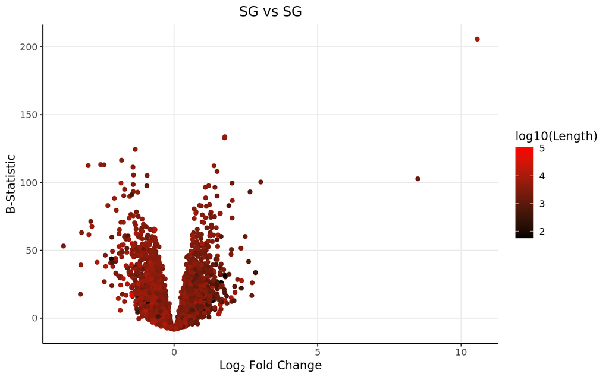

```r
DEGenes_SG.vs.WC$Gene <- row.names(DEGenes_SG.vs.WC)
colnames(genelength) <- c("Length","Gene")
DEGenes_SG.vs.WC <- merge(DEGenes_SG.vs.WC, genelength, by="Gene")

ggplot(data=DEGenes_SG.vs.WC,
                 aes(x=logFC,
                     y=  B)) +
  geom_point(aes(color=log10(Length)))+
  theme_bw() +
  theme(axis.line = element_line(colour = "black"),
        panel.grid.minor = element_blank(),
        panel.border = element_blank(),
        panel.background = element_blank()) +
  ggtitle("SG vs SG")+ xlab(expression(Log[2] ~ Fold ~ Change)) + ylab("B-Statistic") +
  theme(plot.title = element_text(hjust = 0.5))  +
  scale_colour_gradient(low = "black", high = "red")+ theme(text=element_text(family = "Quicksand"))
```

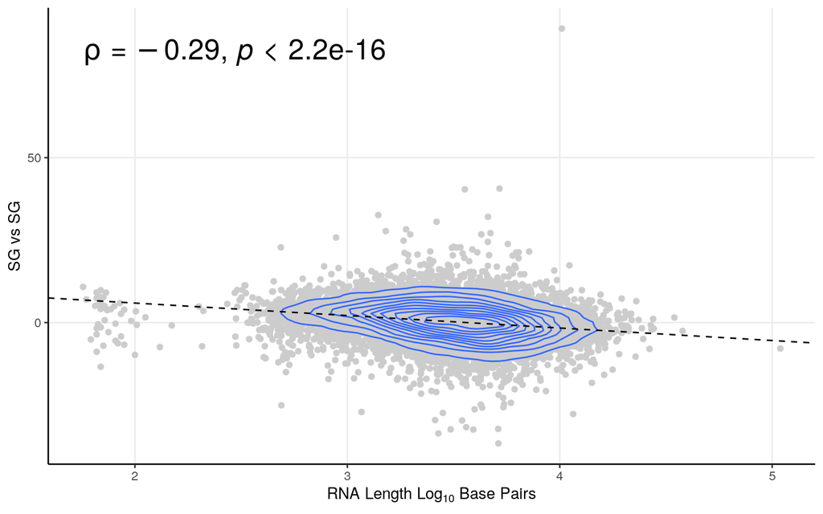

```r
smooth.SG <- lm(t~log10(Length), DEGenes_SG.vs.WC)
liner.SG <- rstandard(smooth.SG)
DEGenes_SG.vs.WC <-cbind(DEGenes_SG.vs.WC, liner.SG)
colnames(DEGenes_SG.vs.WC)[9] <- "Residuals"
row.names(DEGenes_SG.vs.WC) <- DEGenes_SG.vs.WC$Gene
linemarkers <- as.data.frame(DEGenes_SG.vs.WC[abs(DEGenes_SG.vs.WC$Residuals)>4,])

# Calculate the Spearman correlation coefficient
spearman_corr <- cor(DEGenes_SG.vs.WC$t, log10(DEGenes_SG.vs.WC$Length), method = "spearman")



ggplot(DEGenes_SG.vs.WC, aes(y=t, x=log10(Length))) + geom_point(color="#CCCCCC", alpha=1) +   theme_bw()+ geom_density_2d()+
 ylab("SG vs SG") + xlab(expression(RNA ~ Length ~ Log[10] ~ Base ~ Pairs)) +
  theme(axis.line = element_line(colour = "black"),
        panel.grid.minor = element_blank(),
        panel.border = element_blank(),
        panel.background = element_blank()) +
  theme(plot.title = element_text(hjust = 0.5))  +
  geom_abline(slope=smooth.SG$coefficients[2], intercept = smooth.SG$coefficients[1], linetype = "dashed")+ stat_cor(method = "spearman", cor.coef.name = "rho",size=7)
```

A negative lenght bias is seen.

## GSEA

Now that we have our genes of interest, it would also be interesting to see what are the **altered gene sets** between upregulated and downregulated transcripts from the above comparison. Therefore, lets perform a *Gene Set Enrichment Analysis*

```r
#for all genes
DEGenes_SG.vs.WC <- DEGenes_SG.vs.WC[order(DEGenes_SG.vs.WC[,4]),]
gseatool <- DEGenes_SG.vs.WC[,4]
gseatool <- as.data.frame(gseatool)
colnames(gseatool)[1] <- "t"
gseatool[,2] <- DEGenes_SG.vs.WC$Gene
colnames(gseatool)[2] <- "Symbol"
gseatool <- gseatool[,c(2,1)]

vectorranks <- gseatool$t
names(vectorranks) <- gseatool$Symbol


#to load our pathways
hallmarks.gs <- msigdbr(species = "Homo sapiens", collection =  "H")

hallmarks.gsets <- hallmarks.gs %>% split(x = .$gene_symbol, f = .$gs_name)

for (set in names(hallmarks.gsets)){
  hallmarks.gsets[[set]] <- toupper(hallmarks.gsets[[set]])
}

hallmarks.res <- fgsea(pathways = hallmarks.gsets,
                       stats = vectorranks)
hallmarks.res.tidy <- hallmarks.res %>%
  as_tibble() %>%
  arrange(desc(NES))

hallmarks.res.tidy %>%
  dplyr::select(-leadingEdge, -ES) %>%
  arrange(padj)
```

```
## # A tibble: 50 × 6
##    pathway                                     pval     padj log2err   NES  size
##    <chr>                                      <dbl>    <dbl>   <dbl> <dbl> <int>
##  1 HALLMARK_OXIDATIVE_PHOSPHORYLATION      1.92e-15 9.59e-14   1.01   2.50   184
##  2 HALLMARK_MYC_TARGETS_V1                 3.48e-11 8.71e-10   0.851  2.25   191
##  3 HALLMARK_G2M_CHECKPOINT                 8.07e-11 1.34e- 9   0.839  2.23   184
##  4 HALLMARK_E2F_TARGETS                    9.89e-10 1.24e- 8   0.788  2.18   175
##  5 HALLMARK_KRAS_SIGNALING_UP              1.32e- 6 1.32e- 5   0.644 -2.10   100
##  6 HALLMARK_EPITHELIAL_MESENCHYMAL_TRANSI… 2.17e- 6 1.81e- 5   0.627 -1.99   129
##  7 HALLMARK_COAGULATION                    2.85e- 5 2.04e- 4   0.576 -2.06    64
##  8 HALLMARK_ANGIOGENESIS                   1.23e- 3 7.71e- 3   0.455 -1.92    16
##  9 HALLMARK_INTERFERON_ALPHA_RESPONSE      1.63e- 3 8.13e- 3   0.455  1.66    87
## 10 HALLMARK_MITOTIC_SPINDLE                1.54e- 3 8.13e- 3   0.455  1.55   177
## # ℹ 40 more rows
```

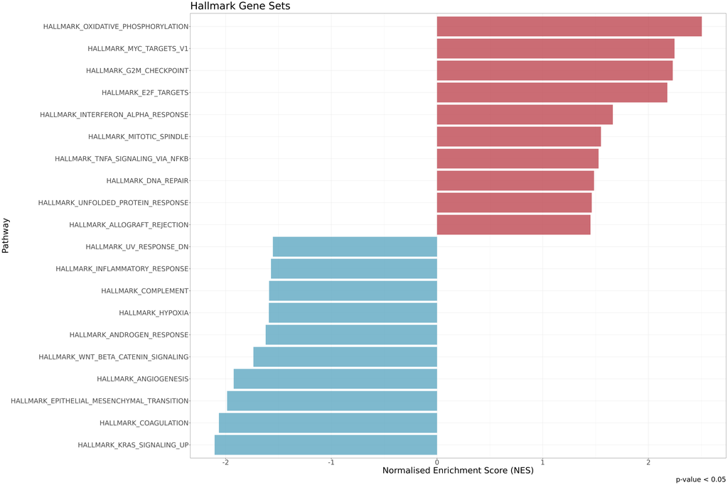

```r
hallmark.sg.t <- hallmarks.res.tidy[,c(1,6)]
hallmark.sg.t <- as.data.frame(hallmark.sg.t)

#this small part is generic
thresh <- 0.05

#this one is no longer generic
data_to_plot <- hallmarks.res.tidy %>% filter(padj < thresh)

statvec <- c()
for (i in 1:nrow(data_to_plot)){
  if (data_to_plot[i,6] > 0){
    status <- "Upregulated"
  }
 else {
   status <- "Downregulated"
 }
statvec <- c(statvec, status)
}

data_to_plot$Status <- statvec

##-----HALMARK-----
gsea_plot_hall <- ggplot(data_to_plot, aes(reorder(pathway, NES), NES)) +
  geom_col(aes(fill= Status), alpha=0.75) + scale_fill_manual(values = c("#53A2BE","#BA3B46"), name = "Regulation Status", labels = c("Downregulated", "Upregulated"), breaks = c("Downregulated", "Upregulated")) +
  coord_flip() +
  labs(x="Pathway", y="Normalised Enrichment Score (NES)",
       title= "Hallmark Gene Sets",
       caption = paste0("p-value < ", thresh)) + theme(plot.title = element_text(hjust = 1)) +
  theme_bw() + theme(text=element_text(family = "Quicksand")) + theme(legend.position = "none")

gsea_plot_hall+
  theme(text=element_text(size=25,  family="Arial MS"))
```

# Complex Linear Models

In here, I use more complex linear models, which in theory allows me to isolate the actual SG transcriptome. Since the polyssome samples are so different, I dont use them in this analysis.

```r
forsample <- c(rep("CMV",12),rep("G3BP1",12),rep("CMV",12),rep("G3BP1",12), rep("Total",24), rep("Polysomal",24))[1:72]
forstress <- c(rep("CTRL",24), rep("Stressed",24), rep("CTRL",12), rep("Stressed",12),rep("CTRL",12), rep("Stressed",12))[1:72]
forsg <- c(rep("No", 36), rep("Yes", 12), rep("No",48))[1:72]

metadata <- data.frame(Sample=forsample, Stress=forstress, SG=forsg)

mm <- model.matrix(~1+Sample*Stress,metadata)

print(mm)
```

```
##    (Intercept) SampleG3BP1 SampleTotal StressStressed
## 1            1           0           0              0
## 2            1           0           0              0
## 3            1           0           0              0
## 4            1           0           0              0
## 5            1           0           0              0
## 6            1           0           0              0
## 7            1           0           0              0
## 8            1           0           0              0
## 9            1           0           0              0
## 10           1           0           0              0
## 11           1           0           0              0
## 12           1           0           0              0
## 13           1           1           0              0
## 14           1           1           0              0
```

[output cut: 139 more lines]

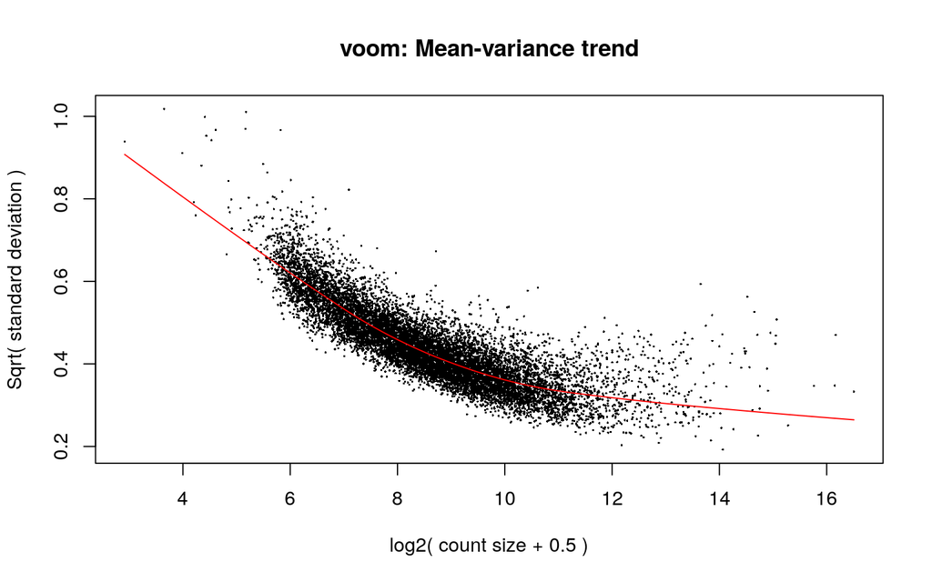

```r
#Here, I center my model matrix
mm[,2] <- mm[,2] - mean(mm[,2])
mm[,3] <- mm[,3] - mean(mm[,3])
mm[,4] <- mm[,4] - mean(mm[,4])
mm[,5] <- mm[,4] * mm[,2]
mm[,6] <- mm[,4] * mm[,3]



D0 <- DGEList(finaltable[,1:72])

#Then we calculate the normalization factors for these new generated data frames
#Bear in mind this step calculates the normalization factors, but does not normalize itself.
D0 <- calcNormFactors(D0)

y <- voom(D0, mm, plot = T)
```

```r
fitted <- lmFit(y$E, mm)


head(coef(fitted))
```

```
##         (Intercept) SampleG3BP1 SampleTotal StressStressed
## 7SK        5.348547 -0.47346141  -2.8414777     0.19928859
## A4GALT     2.383014  0.02647492  -0.2680574     0.15676758
## AAAS       5.400033 -0.10509973  -0.1174765     0.01961751
## AACS       5.262631 -0.05300403  -0.2163353     0.08316369
## AADACP1    3.664666 -0.79364503  -1.1626536     0.11964358
## AADAT      2.862660  0.11078469   0.4654855    -0.07326194
##         SampleG3BP1:StressStressed SampleTotal:StressStressed
## 7SK                      2.0136130                  1.1446684
## A4GALT                  -0.6919916                 -0.6830730
## AAAS                     0.3589069                  0.2429945
## AACS                    -0.2965977                 -0.1530657
## AADACP1                  0.5505442                  0.1982679
## AADAT                   -0.2068941                  0.3506249
```

```r
tmp <- eBayes(fitted)

top.table <- topTable(tmp, 5, sort.by = "logFC", n=Inf)
DEGenes <- top.table
ndegs=20
```

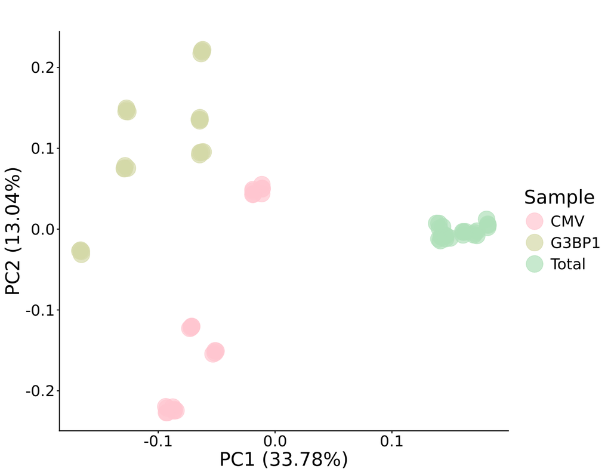

```r
# Define color palette
custom_palette <- qualitative_hcl(8, palette = "Pastel")
custom_palette <- sample(custom_palette, 8)
#custom_palette <- c("#124038","#AD1F36",  "#DBD56E","#5D8DC0")

#This prepares my data for the PCA
dfforpca <- y$E[,c(1:72)]
dfforpca <- t(dfforpca)
dfforpca <- as.data.frame(dfforpca) # needs to be a data.frame
dfforpca <- apply(dfforpca, 2, as.numeric) # Ensure numeric
dfforpca <- as.data.frame(dfforpca) # still needs to be a data.frame

# Add metadata, which we will then use to plot
dfforpca$Sample <- forsample[1:72]
dfforpca$Stress <- forstress[1:72]
dfforpca$SG <- forsg[1:72]
dfforpca$All <- SampleColouring[1:72]

# PCA computation itself. I do one PCA for each variable I want to see.
pca_res <- prcomp(dfforpca[, 1:(ncol(dfforpca)-4)], scale = FALSE)

p_Sample <- autoplot(pca_res, data = dfforpca, x = 1, y = 2, colour = "Sample", size = 8, alpha=0.7) +
  theme_bw() +
  scale_colour_manual(name = "Sample", values = custom_palette) +
  ggtitle("") +
  theme(plot.title = element_text(hjust = 0.5),
        axis.line = element_line(colour = "black"),
        panel.grid.minor = element_blank(),
        panel.border = element_blank(),
        panel.background = element_blank()) + theme_classic() +
  theme(axis.line = element_line(colour = "black")) +
  theme(text=element_text(size=20,  family="Arial MS"))


p_Stress <- autoplot(pca_res, data = dfforpca, x = 1, y = 2, colour = "Stress", size = 8) +
  theme_bw() +
  scale_colour_manual(name = "Stress", values = custom_palette) +
  ggtitle("PCA - Coloured by Stress") +
  theme(plot.title = element_text(hjust = 0.5),
        axis.line = element_line(colour = "black"),
        panel.grid.minor = element_blank(),
        panel.border = element_blank(),
        panel.background = element_blank())

p_SG <- autoplot(pca_res, data = dfforpca, x = 1, y = 2, colour = "SG", size = 8) +
  theme_bw() +
  scale_colour_manual(name = "SG", values = custom_palette) +
  ggtitle("PCA - Coloured by SG") +
  theme(plot.title = element_text(hjust = 0.5),
        axis.line = element_line(colour = "black"),
        panel.grid.minor = element_blank(),
        panel.border = element_blank(),
        panel.background = element_blank())

p_All <- autoplot(pca_res, data = dfforpca, x = 1, y = 2, colour = "All", size = 8) +
  theme_bw() +
  scale_colour_manual(name = "All", values = custom_palette) +
  ggtitle("PCA - Coloured by All") +
  theme(plot.title = element_text(hjust = 0.5),
        axis.line = element_line(colour = "black"),
        panel.grid.minor = element_blank(),
        panel.border = element_blank(),
        panel.background = element_blank())

p_Sample
```

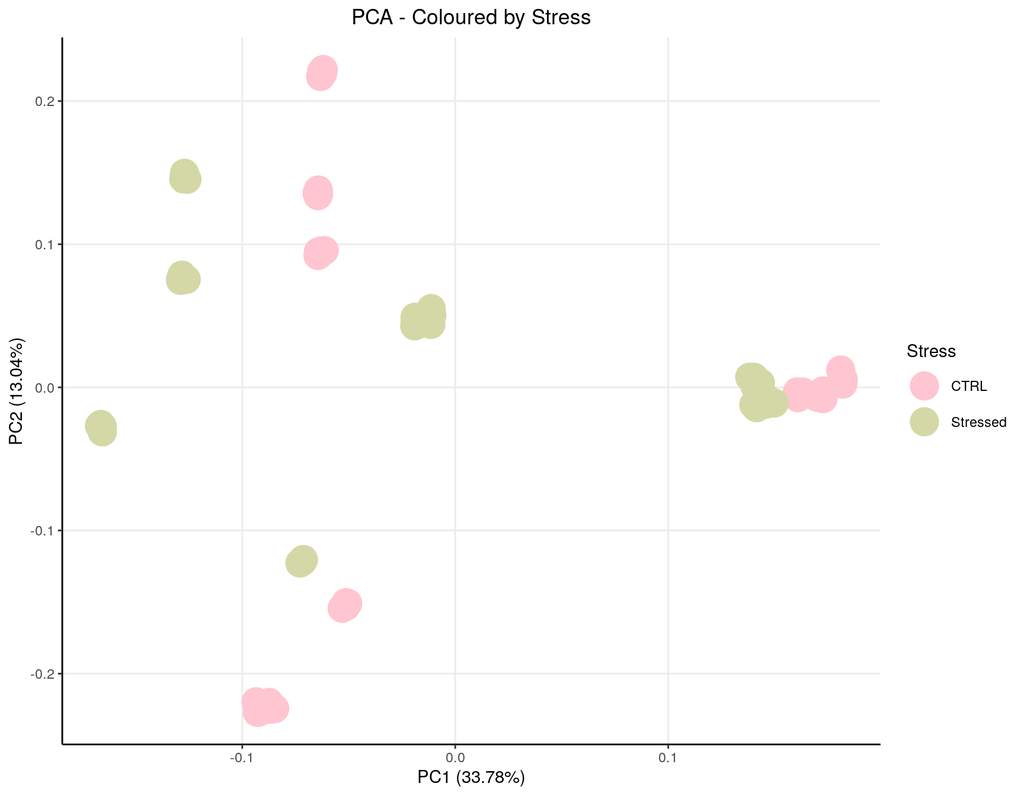

```r
p_Stress
```

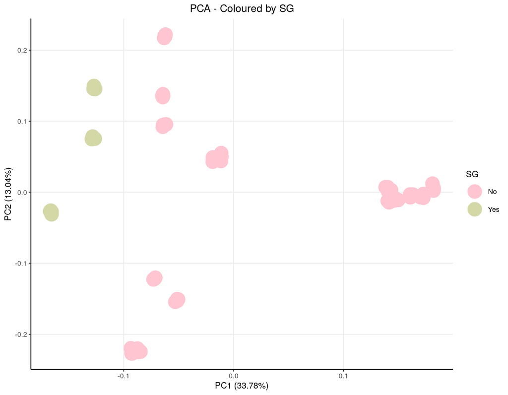

```r
p_SG
```

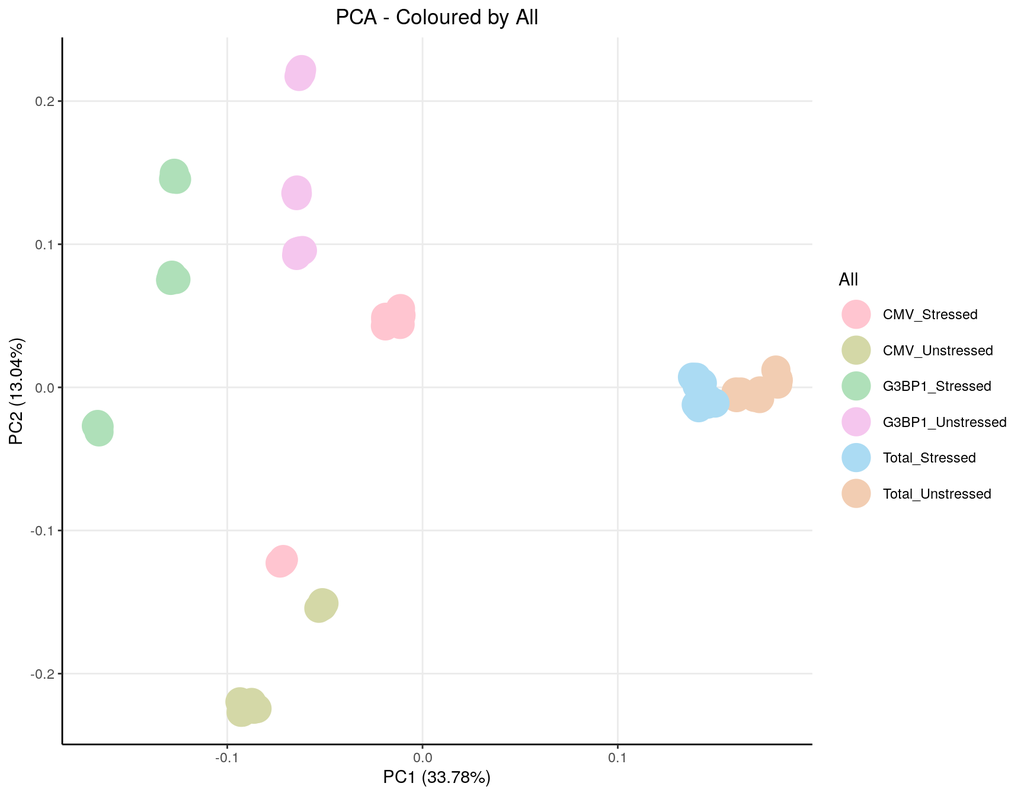

```r
p_All
```

```r
 png("~/Images/PCA_Example4.png", width = 7, height=4, units = "in", res=300)
 p_Sample
 dev.off()
```

```r
#in case you want to see most important genes for PCA yourself
contribs1 <- pca_res$rotation[,1]
contribs2 <- pca_res$rotation[,2]

#These are the biggest contributors to the PCA1 (right side)
(pos1genes <- sort(contribs1, decreasing=T)[1:10])
```

```
##  LINC00326       MMP1     MAP3K5      GPNMB     ITGA10      MMP16      CADM2
## 0.05856913 0.05612261 0.05236556 0.05212660 0.05205447 0.05169518 0.04824729
##      EPHA7       RTL9     IGFBP3
## 0.04795555 0.04689793 0.04600789
```

```r
#These are the biggest contributors to the PCA1 (left side)
(neg1genes <- sort(contribs1, decreasing=F)[1:10])
```

```
##       G3BP1     G3BP1P1       RN7SK         7SK       PADI3   LINC02273
## -0.14109211 -0.10383818 -0.05775489 -0.05773159 -0.05762102 -0.05299710
##        CDK1        HES4      RPL7P9       RPPH1
## -0.05100241 -0.05000356 -0.04812426 -0.04743124
```

```r
#These are the biggest contributors to the PCA2 (up side)
(pos2genes <- sort(contribs2, decreasing=T)[1:10])
```

```
##      G3BP1    G3BP1P1      MARF1       MC5R     PIK3R1     TMEFF1      KLHL1
## 0.21170976 0.19719548 0.05295709 0.04153982 0.03860291 0.03718026 0.03669990
##      CASP3     SEMA3D     CFAP54
## 0.03608688 0.03449660 0.03445935
```

```r
#These are the biggest contributors to the PCA2 (down side)
(neg2genes <- sort(contribs2, decreasing=F)[1:10])
```

```
##        ENAM      CYP1A1       KLKP1   LINC00326       IFNL2       IFNL3
## -0.06537135 -0.05751550 -0.05343498 -0.05072325 -0.04848588 -0.04699724
##        NGFR     CEACAM6         VGF  ANXA2R-OT1
## -0.04569897 -0.04278357 -0.04237182 -0.04042376
```

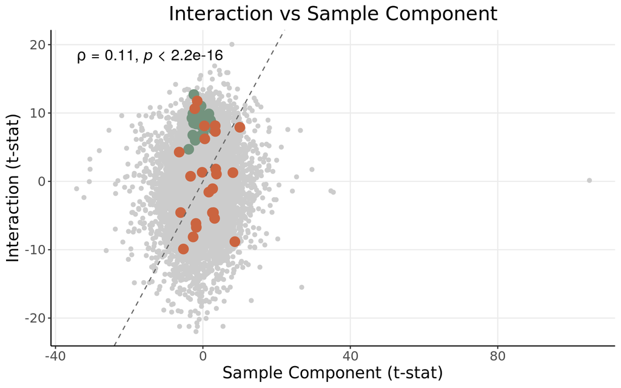

```r
# Pull t-stats for the interaction and its two main-effect components
top_interact <- topTable(tmp, coef=5, sort.by="logFC", n=Inf)   # SampleG3BP1:StressStressed
top_sample   <- topTable(tmp, coef=2, sort.by="logFC", n=Inf)   # SampleG3BP1 (main effect)
top_stress   <- topTable(tmp, coef=4, sort.by="logFC", n=Inf)   # StressStressed (main effect)

interact_t <- data.frame(Gene=row.names(top_interact), interact_t=top_interact$t)
sample_t   <- data.frame(Gene=row.names(top_sample), sample_t=top_sample$t)
stress_t   <- data.frame(Gene=row.names(top_stress), stress_t=top_stress$t)

MitoGenes <- fread("~/MitoGenes.txt")[[1]]
NucGenes <- fread("~/rnalocate_mito_filt.csv")[[1]]

## ---- Interaction vs Sample (G3BP1) component ----

comp1_df <- merge(interact_t, sample_t, by="Gene")
row.names(comp1_df) <- comp1_df$Gene
MitoData_c1 <- comp1_df[comp1_df$Gene %in% MitoGenes, ]
NucData_c1  <- comp1_df[comp1_df$Gene %in% NucGenes, ]

spearman_c1 <- cor(comp1_df$interact_t, comp1_df$sample_t, method = "spearman")

(p_c1 <- ggplot(comp1_df, aes(x=sample_t, y=interact_t)) +
  geom_point(color="#CCCCCC") +
  geom_point(data=MitoData_c1, aes(x=sample_t, y=interact_t), color="#73937E", size=4) +
  geom_point(data=NucData_c1, aes(x=sample_t, y=interact_t), color="#CB643F", size=4) +
  geom_abline(slope=1, intercept=0, linetype="dashed", color="grey40") +
  theme_bw() + ylab("Interaction (t-stat)") + xlab("Sample Component (t-stat)") +
  theme(axis.line = element_line(colour = "black"),
        panel.grid.minor = element_blank(),
        panel.border = element_blank(),
        panel.background = element_blank()) +
  ggtitle("Interaction vs Sample Component") +
  theme(plot.title = element_text(hjust = 0.5)) +
  theme(text=element_text(size=15, family="Arial MS")) +
  stat_cor(method = "spearman", cor.coef.name = "rho", size=5))
```

```r
png("~/Projects/StressGranules/SGPAPER/Images/PNG/InteractionVsSample_Soma.png", width = 7, height=6, units = "in", res=300)
p_c1
dev.off()
```

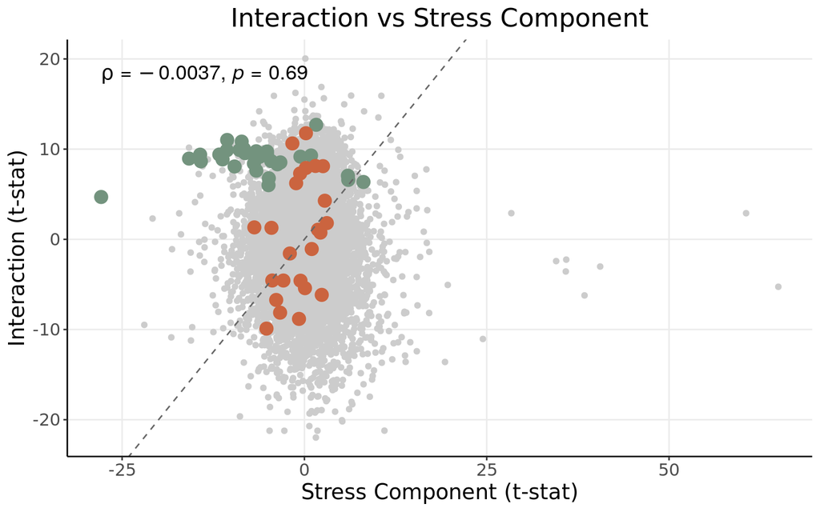

```r
## ---- Interaction vs Stress component ----

comp2_df <- merge(interact_t, stress_t, by="Gene")
row.names(comp2_df) <- comp2_df$Gene
MitoData_c2 <- comp2_df[comp2_df$Gene %in% MitoGenes, ]
NucData_c2  <- comp2_df[comp2_df$Gene %in% NucGenes, ]

spearman_c2 <- cor(comp2_df$interact_t, comp2_df$stress_t, method = "spearman")

(p_c2 <- ggplot(comp2_df, aes(x=stress_t, y=interact_t)) +
  geom_point(color="#CCCCCC") +
  geom_point(data=MitoData_c2, aes(x=stress_t, y=interact_t), color="#73937E", size=4) +
  geom_point(data=NucData_c2, aes(x=stress_t, y=interact_t), color="#CB643F", size=4) +
  geom_abline(slope=1, intercept=0, linetype="dashed", color="grey40") +
  theme_bw() + ylab("Interaction (t-stat)") + xlab("Stress Component (t-stat)") +
  theme(axis.line = element_line(colour = "black"),
        panel.grid.minor = element_blank(),
        panel.border = element_blank(),
        panel.background = element_blank()) +
  ggtitle("Interaction vs Stress Component") +
  theme(plot.title = element_text(hjust = 0.5)) +
  theme(text=element_text(size=15, family="Arial MS")) +
  stat_cor(method = "spearman", cor.coef.name = "rho", size=5))
```

```r
png("~/Projects/StressGranules/SGPAPER/Images/PNG/InteractionVsStress_Soma.png", width = 7, height=6, units = "in", res=300)
p_c2
dev.off()
```

## Volcano Plot

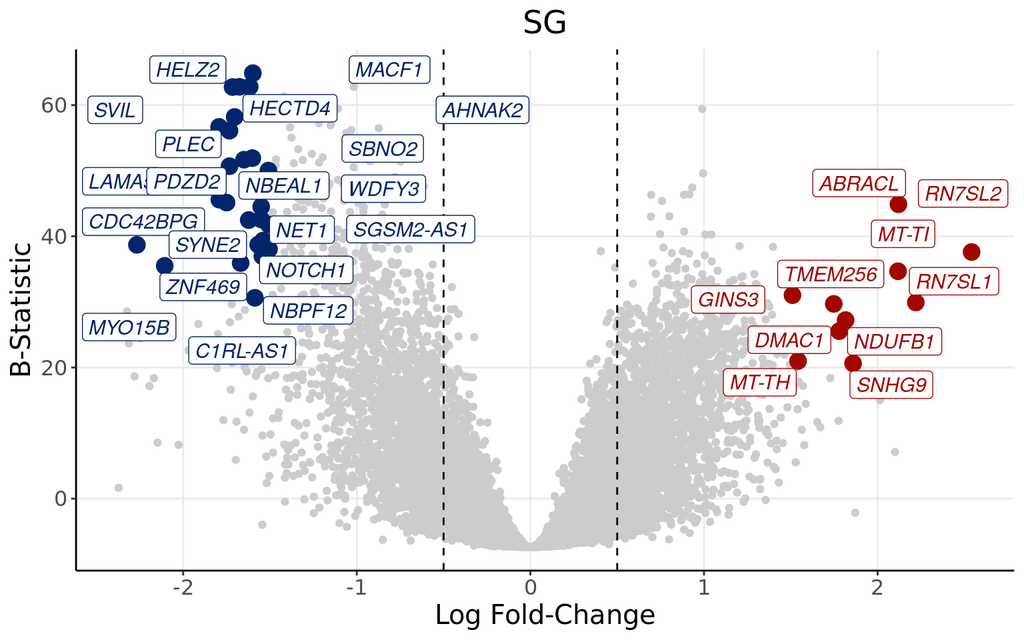

```r
upmarkers <- as.data.frame(DEGenes[DEGenes$logFC>1.5 & DEGenes$B>20,] )
downmarkers <- as.data.frame(DEGenes[DEGenes$logFC< -1.5 & DEGenes$B>30,] )

ggplot(data=DEGenes,
                 aes(x=logFC,
                     y=  B)) +
  geom_point(color="#CCCCCC")+ geom_vline(xintercept = -0.5, linetype="dashed")+geom_vline(xintercept = 0.5, linetype="dashed")+
  theme_bw() + ylab("B-Statistic")+xlab("Log Fold-Change")+
  theme(axis.line = element_line(colour = "black"),
        panel.grid.minor = element_blank(),
        panel.border = element_blank(),
        panel.background = element_blank()) +
  ggtitle("SG")+
  theme(plot.title = element_text(hjust = 0.5), plot.subtitle = element_text(hjust = 0.5)) +
  geom_point(data=upmarkers, aes(x=logFC, y=  B), color="#A10702",size=4)+
  geom_point(data=downmarkers, aes(x=logFC, y=  B), color="#03256C",size=4)+
  geom_label_repel(upmarkers[1:ndegs,] , mapping=aes(label=row.names(upmarkers)[1:ndegs]),size=4,point.padding=-0.5, color="#A10702",max.overlaps = 20, fontface="italic")+
  geom_label_repel(downmarkers[1:ndegs,] , mapping=aes(label=row.names(downmarkers)[1:ndegs]),size=4,point.padding=-0.5, color="#03256C",max.overlaps = 20, fontface="italic")+
  theme(text=element_text(size=15,  family="Arial MS"))
```

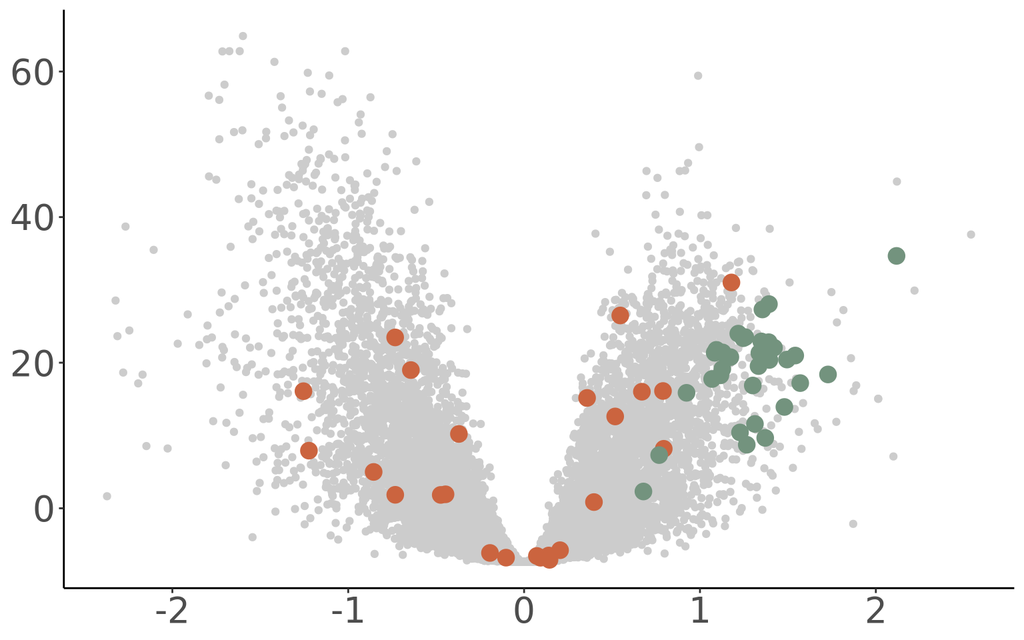

```r
write.table(DEGenes, "~/Projects/StressGranules/SGPAPER/RealSGs/RealSoma.txt", row.names=T, col.names = T)


MitoGenes <- fread("~/MitoGenes.txt")[[1]]
MitoData <- DEGenes[rownames(DEGenes) %in% MitoGenes, ]
NucGenes <- fread("~/rnalocate_mito_filt.csv")[[1]]
NucData <- DEGenes[rownames(DEGenes) %in% NucGenes, ]
(m <- ggplot(data=DEGenes,
                 aes(x=logFC,
                     y=B)) +
  geom_point(color="#CCCCCC") +
  geom_point(data=NucData, aes(x=logFC, y=B), color="#CB643F", size=4) +
  geom_point(data=MitoData, aes(x=logFC, y=B), color="#73937E", size=4) +
  ylab("B-Statistic") +
  xlab(expression(Log[2]~"Fold-Change")) +
  theme(
    axis.line = element_line(colour = "black"),
    panel.grid.major = element_blank(),   # remove major gridlines
    panel.grid.minor = element_blank(),   # remove minor gridlines
    panel.border = element_blank(),
    panel.background = element_blank(),
    axis.title = element_blank()
  ) +
  theme(plot.title = element_text(hjust = 0.5), plot.subtitle = element_text(hjust = 0.5)) +
  theme(text=element_text(size=25, family="Arial MS")))
```

```r
png("~/Projects/StressGranules/SGPAPER/Images/PNG/SomaMito.png", width = 7, height=6, units = "in", res=300)
m
dev.off()
```

# MA Plot

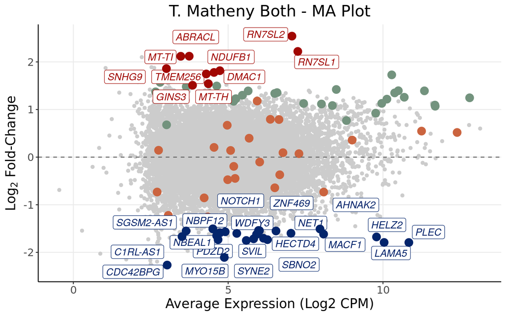

```r
# MA plot: mean expression (x) vs logFC (y), same highlighting scheme as the volcano

ggplot(data=DEGenes,
                 aes(x=AveExpr,
                     y=logFC)) +
  geom_point(color="#CCCCCC") +
  geom_point(data=MitoData, aes(x=AveExpr, y=logFC), color="#73937E", size=4) +
  geom_point(data=NucData, aes(x=AveExpr, y=logFC), color="#CB643F", size=4) +
  geom_hline(yintercept = 0, linetype="dashed", color="grey40") +
  theme_bw() + ylab(expression(Log[2]~"Fold-Change")) + xlab("Average Expression (Log2 CPM)") +
  theme(axis.line = element_line(colour = "black"),
        panel.grid.minor = element_blank(),
        panel.border = element_blank(),
        panel.background = element_blank()) +
  ggtitle("T. Matheny Both - MA Plot") +
  theme(plot.title = element_text(hjust = 0.5), plot.subtitle = element_text(hjust = 0.5)) +
  geom_label_repel(upmarkers[1:ndegs,], mapping=aes(x=AveExpr, y=logFC, label=row.names(upmarkers)[1:ndegs]), size=4, point.padding=-0.5, color="#A10702", max.overlaps=20, fontface="italic") +
  geom_label_repel(downmarkers[1:ndegs,], mapping=aes(x=AveExpr, y=logFC, label=row.names(downmarkers)[1:ndegs]), size=4, point.padding=-0.5, color="#03256C", max.overlaps=20, fontface="italic") +
  geom_point(data=upmarkers, aes(x=AveExpr, y=logFC), color="#A10702", size=4) +
  geom_point(data=downmarkers, aes(x=AveExpr, y=logFC), color="#03256C", size=4) +
  theme(text=element_text(size=15, family="Arial MS"))
```

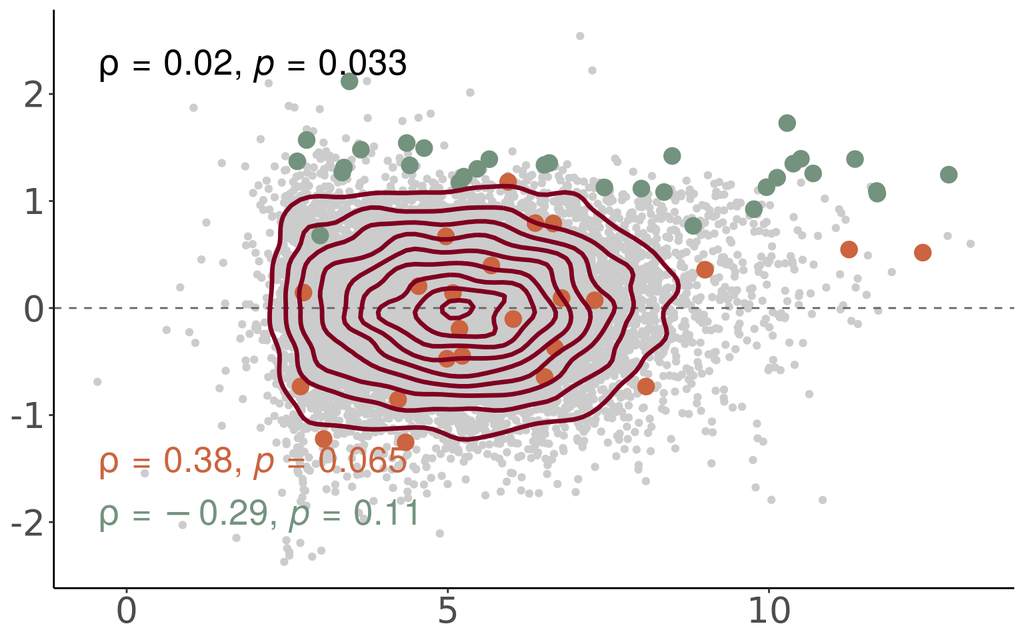

```r
# Publication-style version, stripped of axis titles, matching your "m" plot
(ma <- ggplot(data=DEGenes,
                 aes(x=AveExpr,
                     y=logFC)) +
  geom_point(color="#CCCCCC") +
  geom_point(data=MitoData, aes(x=AveExpr, y=logFC), color="#73937E", size=4) +
  geom_point(data=NucData, aes(x=AveExpr, y=logFC), color="#CB643F", size=4) +
  geom_hline(yintercept = 0, linetype="dashed", color="grey40") +
  ylab(expression(Log[2]~"Fold-Change")) + geom_density2d(color = "#800020", size = 1.2) + stat_cor(method = "spearman", cor.coef.name = "rho", size=7)+
  stat_cor(data = MitoData, aes(x=AveExpr, y=logFC), method = "spearman",
           cor.coef.name = "rho", size=7, color = "#73937E", label.y.npc = 0.1) +
  stat_cor(data = NucData, aes(x=AveExpr, y=logFC), method = "spearman",
           cor.coef.name = "rho", size=7, color = "#CB643F", label.y.npc = 0.2) +
  xlab("Average Expression (Log2 CPM)") +
  theme(
    axis.line = element_line(colour = "black"),
    panel.grid.major = element_blank(),
    panel.grid.minor = element_blank(),
    panel.border = element_blank(),
    panel.background = element_blank(),
    axis.title = element_blank()
  ) +
  theme(plot.title = element_text(hjust = 0.5), plot.subtitle = element_text(hjust = 0.5)) +
  theme(text=element_text(size=25, family="Arial MS")))
```

```r
png("~/Projects/StressGranules/SGPAPER/Images/PNG/SomaMito_MA.png", width = 7, height=6, units = "in", res=300)
ma
dev.off()
```

## MA Plot

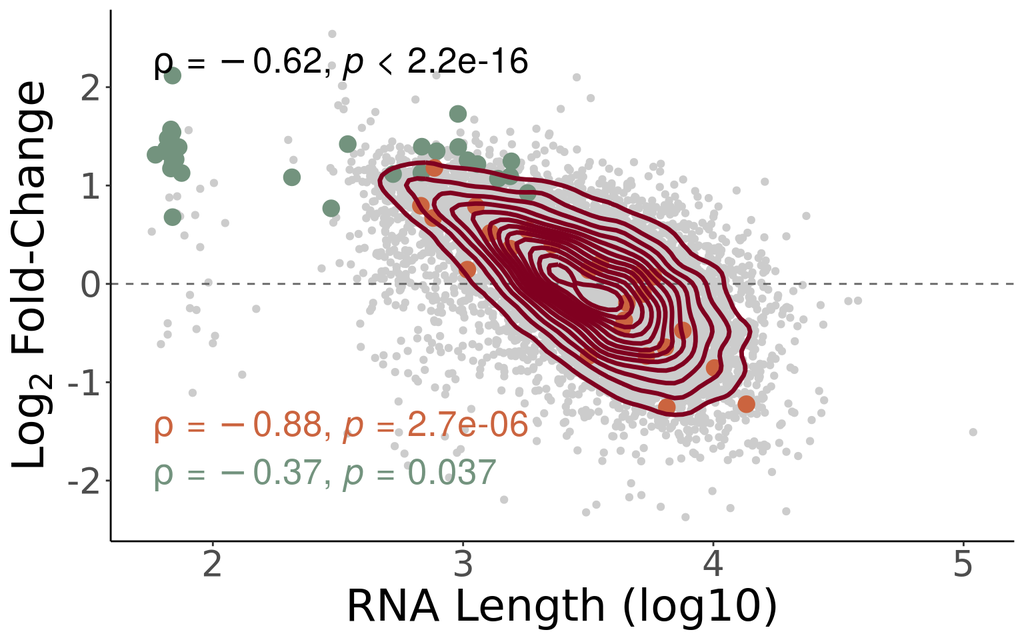

```r
MitoGenes <- fread("~/MitoGenes.txt")[[1]]

genelength <- read.csv("~/Projects/StressGranules/SG_Transcriptome/RP_Data_2021/TrimmedSamples/alignment_STAR/TranscriptLenght.txt", header=T)
genelength <- subset(genelength, Ensembl.Canonical==1)
genelength <- subset(genelength, Gene.name!="")
genelength <- genelength %>%
  group_by(Gene.name) %>%
  slice(which.max(Transcript.length..including.UTRs.and.CDS.)) %>%
  ungroup()
genelength <- genelength[,-c(2,3)]
colnames(genelength) <- c("Length", "Gene")

genelength$Cromo <- ifelse(genelength$Gene %in% MitoGenes, "Mito", "Other")

# Apply the length-based weight formula
genelength$S <- ifelse(
  genelength$Cromo == "Mito",
  (genelength$Length)^(1/3) * 3.23e-11 + 1.17e-9,   # Formula for mitochondrial RNAs
  (genelength$Length)^(1/3) * 6.09e-11 + 3.88e-10    # Formula for other RNAs
)
DEGenes$Gene <- row.names(DEGenes)
DEGenes <- merge(DEGenes, genelength, by="Gene")
MitoGenes <- fread("~/MitoGenes.txt")[[1]]
MitoData <- DEGenes[DEGenes$Gene %in% MitoGenes, ]
NucGenes <- fread("~/rnalocate_mito_filt.csv")[[1]]
NucData <- DEGenes[DEGenes$Gene %in% NucGenes, ]

# Publication-style version, stripped of axis titles, matching your "m" plot
(ma <- ggplot(data=DEGenes,
                 aes(x=log10(Length),
                     y=logFC)) +
  geom_point(color="#CCCCCC") +
  geom_point(data=MitoData, aes(x=log10(Length), y=logFC), color="#73937E", size=4) +
  geom_point(data=NucData, aes(x=log10(Length), y=logFC), color="#CB643F", size=4) +
  geom_hline(yintercept = 0, linetype="dashed", color="grey40") +
  ylab(expression(Log[2]~"Fold-Change")) + geom_density2d(color = "#800020", size = 1.2) + stat_cor(method = "spearman", cor.coef.name = "rho", size=7)+
  stat_cor(data = MitoData, aes(x=log10(Length), y=logFC), method = "spearman",
           cor.coef.name = "rho", size=7, color = "#73937E", label.y.npc = 0.1) +
  stat_cor(data = NucData, aes(x=log10(Length), y=logFC), method = "spearman",
           cor.coef.name = "rho", size=7, color = "#CB643F", label.y.npc = 0.2) +
  xlab("RNA Length (log10)") +
  theme(
    axis.line = element_line(colour = "black"),
    panel.grid.major = element_blank(),
    panel.grid.minor = element_blank(),
    panel.border = element_blank(),
    panel.background = element_blank()
  ) +
  theme(plot.title = element_text(hjust = 0.5), plot.subtitle = element_text(hjust = 0.5)) +
  theme(text=element_text(size=25, family="Arial MS")))
```

```r
png("~/Projects/StressGranules/SGPAPER/Images/PNG/SomaMito_MA_length.png", width = 7, height=6, units = "in", res=300)
ma
dev.off()
```

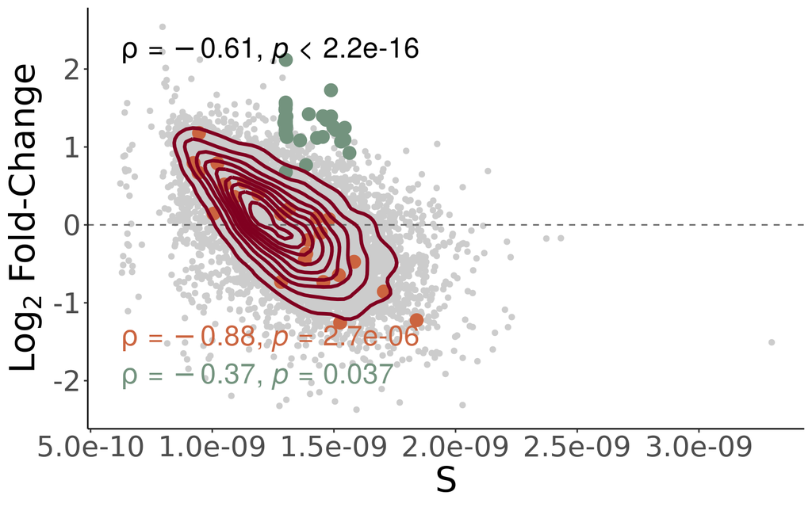

```r
# Publication-style version, stripped of axis titles, matching your "m" plot
(ma <- ggplot(data=DEGenes,
                 aes(x=(S),
                     y=logFC)) +
  geom_point(color="#CCCCCC") +
  geom_point(data=MitoData, aes(x=(S), y=logFC), color="#73937E", size=4) +
  geom_point(data=NucData, aes(x=(S), y=logFC), color="#CB643F", size=4) +
  geom_hline(yintercept = 0, linetype="dashed", color="grey40") +
  ylab(expression(Log[2]~"Fold-Change")) + geom_density2d(color = "#800020", size = 1.2) + stat_cor(method = "spearman", cor.coef.name = "rho", size=7)+
  stat_cor(data = MitoData, aes(x=S, y=logFC), method = "spearman",
           cor.coef.name = "rho", size=7, color = "#73937E", label.y.npc = 0.1) +
  stat_cor(data = NucData, aes(x=S, y=logFC), method = "spearman",
           cor.coef.name = "rho", size=7, color = "#CB643F", label.y.npc = 0.2) +
  xlab("S") +
  theme(
    axis.line = element_line(colour = "black"),
    panel.grid.major = element_blank(),
    panel.grid.minor = element_blank(),
    panel.border = element_blank(),
    panel.background = element_blank()
  ) +
  theme(plot.title = element_text(hjust = 0.5), plot.subtitle = element_text(hjust = 0.5)) +
  theme(text=element_text(size=25, family="Arial MS")))
```

```r
png("~/Projects/StressGranules/SGPAPER/Images/PNG/SomaMito_MA_S.png", width = 7, height=6, units = "in", res=300)
ma
dev.off()
```

## Mito / Nuc Signature Violin

```r
library(data.table)
library(dplyr)
library(ggplot2)
library(rstatix)
# ── 0. Subset to the samples that take part in the SampleG3BP1:StressStressed interaction ──
# These are the CMV and G3BP1 arms only (indices 1:48); the Total arm is not part of this coefficient
interact_idx <- which(metadata$Sample %in% c("CMV", "G3BP1"))

expression.df <- y$E[, interact_idx]
sample_grp <- metadata$Sample[interact_idx]
stress_grp <- metadata$Stress[interact_idx]

# Combined 4-level grouping for the x-axis, keeps Sample and Stress crossed and visible
Condition <- interaction(sample_grp, stress_grp, sep=".")

custom_palette <- c(
  "CMV.CTRL"       = "#a2d1e6",
  "CMV.Stressed"   = "#769fca",
  "G3BP1.CTRL"     = "#e88184",
  "G3BP1.Stressed" = "#de425b"
)

# ── 1. Gene sets already loaded earlier in the script (MitoGenes, NucGenes) ──
mito_genes_present <- MitoGenes[MitoGenes %in% rownames(expression.df)]
nuc_genes_present  <- NucGenes[NucGenes %in% rownames(expression.df)]
cat(length(mito_genes_present), "Mito genes found in expression matrix\n")
```

```
## 32 Mito genes found in expression matrix
```

```r
cat(length(nuc_genes_present), "Nuc genes found in expression matrix\n")
```

```
## 24 Nuc genes found in expression matrix
```

```r
# ── 2. Rank all genes per sample (1 = least expressed) ───────────────────────
rank_matrix <- apply(expression.df, 2, function(x) rank(x, ties.method = "average"))
rank_matrix <- as.data.frame(rank_matrix)

# ── 3. Compute a rank-sum score per sample, one gene set at a time ───────────
compute_score <- function(genes, rank_matrix, n_total) {
  colSums(rank_matrix[genes, , drop = FALSE]) / n_total
}

mito_score <- compute_score(mito_genes_present, rank_matrix, nrow(expression.df))
nuc_score  <- compute_score(nuc_genes_present, rank_matrix, nrow(expression.df))

# ── 4. Assemble plot dataframe, long format across both gene sets ────────────
score_df <- rbind(
  data.frame(Sample = colnames(expression.df), Score = as.numeric(mito_score),
             SampleGrp = sample_grp, StressGrp = stress_grp,
             Condition = Condition, GeneSet = "Mito"),
  data.frame(Sample = colnames(expression.df), Score = as.numeric(nuc_score),
             SampleGrp = sample_grp, StressGrp = stress_grp,
             Condition = Condition, GeneSet = "Nuc")
)

# ── 5. Statistics per gene set: two-way ANOVA (Sample*Stress), interaction term ──
# This checks if the gene set's score is significantly driven by the interaction,
# same logic as the t-stat scatter plots - is it more than the sum of its components?
stat_labels <- score_df %>%
  group_by(GeneSet) %>%
  group_modify(~{
    aov_res  <- aov(Score ~ SampleGrp * StressGrp, data = .x)
    aov_tidy <- summary(aov_res)

    # The interaction term is the third row of the ANOVA table
    p_raw  <- aov_tidy[[1]][["Pr(>F)"]][3]
    p_adj  <- p.adjust(p_raw, method = "BH")

    ss_interact <- aov_tidy[[1]][["Sum Sq"]][3]
    ss_total    <- sum(aov_tidy[[1]][["Sum Sq"]])
    eta_sq      <- ss_interact / ss_total
    cohens_f    <- sqrt(eta_sq / (1 - eta_sq))

    data.frame(
      label = paste0("Interaction Cohen's f = ", round(cohens_f, 3),
                      "\nadj. p = ", formatC(p_adj, format = "e", digits = 2))
    )
  })

# ── 6. Plot ───────────────────────────────────────────────────────────────────
vilsigplot <- ggplot(score_df, aes(x = Condition, y = Score, fill = Condition)) +
  geom_violin(colour = "black", alpha = 0.6, trim = FALSE) +
  geom_point(
    position = position_jitter(width = 0.1),
    alpha    = 0.7,
    size     = 1.5
  ) +
  stat_summary(fun = mean,   geom = "point", shape = 18,
               size = 3, colour = "black") +
  stat_summary(fun = median, geom = "point", shape = 17,
               size = 3, colour = "black") +
  geom_text(
    data  = stat_labels,
    aes(x = -Inf, y = Inf, label = label),
    hjust = -0.05, vjust = 1.2,
    size  = 4, fontface = "bold", lineheight = 1.1,
    inherit.aes = FALSE
  ) +
  facet_wrap(~GeneSet, scales = "free_y") +
  scale_fill_manual(values = custom_palette) +
  labs(
    x     = "Sample : Stress",
    y     = "Signature Score (Rank Sum)",
    title = "Mitochondrial vs Nuclear-Localized Gene Scores - G3BP1 Interaction"
  ) +
  theme_bw() +
  theme(
    plot.title      = element_text(hjust = 0.5, size = 14, face = "bold"),
    axis.text.x     = element_text(size = 12, angle=20, hjust=1),
    strip.text      = element_text(size = 12, face = "bold"),
    legend.position = "none"
  )

png("~/Projects/StressGranules/SGPAPER/Images/PNG/Soma_InteractionMitoSigs.png", width = 14, height=6, units = "in", res=300)
vilsigplot
dev.off()
```

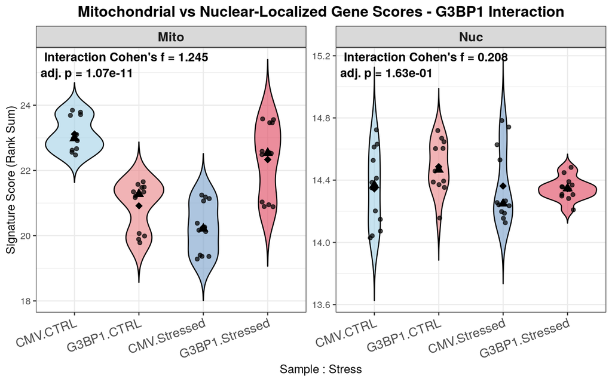

```r
vilsigplot
```

## Volcano Plot with Gene Length

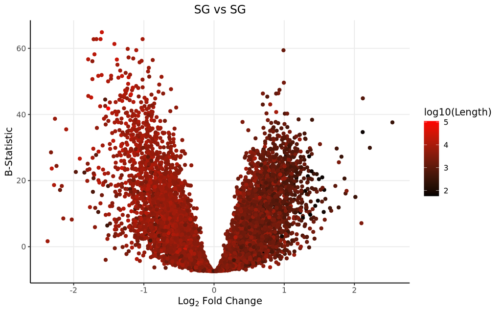

```r
ggplot(data=DEGenes,
                 aes(x=logFC,
                     y=  B)) +
  geom_point(aes(color=log10(Length)))+
  theme_bw() +
  theme(axis.line = element_line(colour = "black"),
        panel.grid.minor = element_blank(),
        panel.border = element_blank(),
        panel.background = element_blank()) +
  ggtitle("SG vs SG")+ xlab(expression(Log[2] ~ Fold ~ Change)) + ylab("B-Statistic") +
  theme(plot.title = element_text(hjust = 0.5))  +
  scale_colour_gradient(low = "black", high = "red")+ theme(text=element_text(family = "Quicksand"))
```

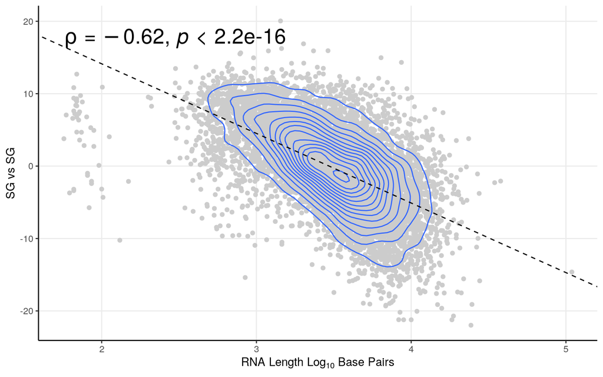

```r
smooth.SG <- lm(t~log10(Length), DEGenes)
liner.SG <- rstandard(smooth.SG)
DEGenes <-cbind(DEGenes, liner.SG)
colnames(DEGenes)[11] <- "Residuals"
row.names(DEGenes) <- DEGenes$Gene
linemarkers <- as.data.frame(DEGenes[abs(DEGenes$Residuals)>4,])

# Calculate the Spearman correlation coefficient
spearman_corr <- cor(DEGenes$t, log10(DEGenes$Length), method = "spearman")



ggplot(DEGenes, aes(y=t, x=log10(Length))) + geom_point(color="#CCCCCC", alpha=1) +   theme_bw()+ geom_density_2d()+
 ylab("SG vs SG") + xlab(expression(RNA ~ Length ~ Log[10] ~ Base ~ Pairs)) +
  theme(axis.line = element_line(colour = "black"),
        panel.grid.minor = element_blank(),
        panel.border = element_blank(),
        panel.background = element_blank()) +
  theme(plot.title = element_text(hjust = 0.5))  +
  geom_abline(slope=smooth.SG$coefficients[2], intercept = smooth.SG$coefficients[1], linetype = "dashed")+ stat_cor(method = "spearman", cor.coef.name = "rho",size=7)
```

Massive negative lenght bias.

## GSEA

Now that we have our genes of interest, it would also be interesting to see what are the **altered gene sets** between upregulated and downregulated transcripts from the above comparison. Therefore, lets perform a *Gene Set Enrichment Analysis*

```r
#for all genes
DEGenes <- DEGenes[order(DEGenes[,4]),]
gseatool <- DEGenes[,4]
gseatool <- as.data.frame(gseatool)
colnames(gseatool)[1] <- "t"
gseatool[,2] <- DEGenes$Gene
colnames(gseatool)[2] <- "Symbol"
gseatool <- gseatool[,c(2,1)]

vectorranks <- gseatool$t
names(vectorranks) <- gseatool$Symbol


#to load our pathways
hallmarks.gs <- msigdbr(species = "Homo sapiens", collection =  "H")

hallmarks.gsets <- hallmarks.gs %>% split(x = .$gene_symbol, f = .$gs_name)

for (set in names(hallmarks.gsets)){
  hallmarks.gsets[[set]] <- toupper(hallmarks.gsets[[set]])
}

hallmarks.res <- fgsea(pathways = hallmarks.gsets,
                       stats = vectorranks)
hallmarks.res.tidy <- hallmarks.res %>%
  as_tibble() %>%
  arrange(desc(NES))

hallmarks.res.tidy %>%
  dplyr::select(-leadingEdge, -ES) %>%
  arrange(padj)
```

```
## # A tibble: 50 × 6
##    pathway                                pval     padj log2err   NES  size
##    <chr>                                 <dbl>    <dbl>   <dbl> <dbl> <int>
##  1 HALLMARK_OXIDATIVE_PHOSPHORYLATION 4.69e-34 2.34e-32   1.52   3.24   184
##  2 HALLMARK_MITOTIC_SPINDLE           1.05e-25 2.62e-24   1.31  -2.90   177
##  3 HALLMARK_MYC_TARGETS_V1            2.43e-25 4.05e-24   1.30   2.92   191
##  4 HALLMARK_DNA_REPAIR                5.56e- 8 6.95e- 7   0.720  2.10   135
##  5 HALLMARK_UV_RESPONSE_DN            9.70e- 8 9.70e- 7   0.705 -2.17   110
##  6 HALLMARK_MTORC1_SIGNALING          3.43e- 7 2.85e- 6   0.675  1.93   176
##  7 HALLMARK_FATTY_ACID_METABOLISM     1.43e- 6 1.02e- 5   0.644  1.98   121
##  8 HALLMARK_HEDGEHOG_SIGNALING        2.70e- 4 1.69e- 3   0.498 -2.01    18
##  9 HALLMARK_APICAL_JUNCTION           3.82e- 4 1.91e- 3   0.498 -1.68   132
## 10 HALLMARK_MYOGENESIS                3.65e- 4 1.91e- 3   0.498 -1.77   100
## # ℹ 40 more rows
```

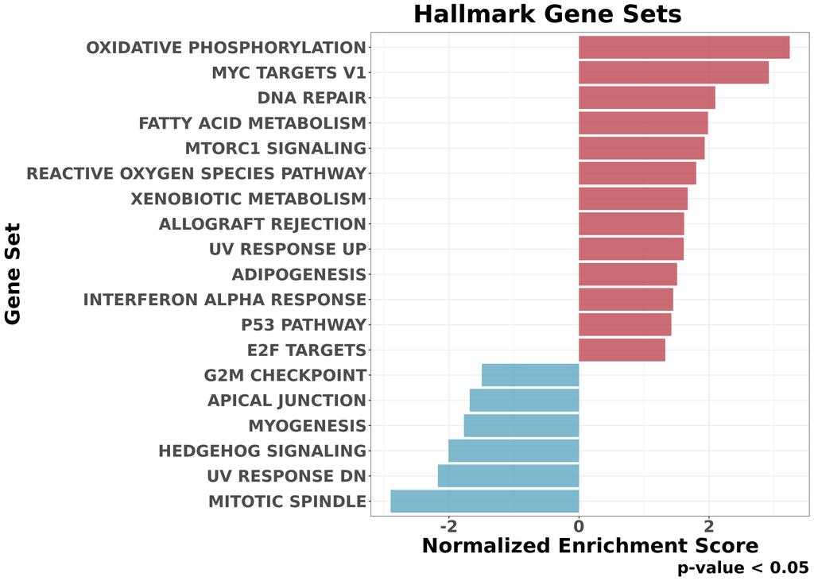

```r
hallmark.sg.t <- hallmarks.res.tidy[,c(1,6)]
hallmark.sg.t <- as.data.frame(hallmark.sg.t)

#this small part is generic
thresh <- 0.05

#this one is no longer generic
data_to_plot <- hallmarks.res.tidy %>%
  filter(padj < thresh) %>%
  mutate(pathway = gsub("^HALLMARK_", "", pathway),
         pathway = gsub("_", " ", pathway))

statvec <- c()
for (i in 1:nrow(data_to_plot)){
  if (data_to_plot[i,6] > 0){
    status <- "Upregulated"
  }
 else {
   status <- "Downregulated"
 }
statvec <- c(statvec, status)
}

data_to_plot$Status <- statvec

##-----HALMARK-----
(SomaGSEA <- ggplot(data_to_plot, aes(reorder(pathway, NES), NES)) +
  geom_col(aes(fill = Status), alpha = 0.75) +
  scale_fill_manual(values = c("#53A2BE", "#BA3B46"),
                    name = "Regulation Status",
                    labels = c("Downregulated", "Upregulated"),
                    breaks = c("Downregulated", "Upregulated")) +
  coord_flip() +
  labs(x = "Gene Set",
       y = "Normalized Enrichment Score",
       title = "Hallmark Gene Sets",
       caption = paste0("p-value < ", thresh)) +
  theme_bw() +
  theme(legend.position = "none",
        text = element_text(size = 25, family = "Arial MS", face = "bold"),
        plot.title = element_text(hjust = 0.25, face = "bold"),
        axis.title = element_text(face = "bold"),
        axis.text = element_text(face = "bold"),
        legend.title = element_text(face = "bold"),
        legend.text = element_text(face = "bold")))
```

```r
png("~/Projects/StressGranules/SGPAPER/Images/PNG/SomaGSEA.png", width = 14, height=10, units = "in", res=300)
SomaGSEA
dev.off()
```

### For Mito

```r
# --- Rank genes by t-statistic as usual ---
DEGenes <- DEGenes[order(DEGenes[,4]),]
gseatool <- DEGenes[,4]
gseatool <- as.data.frame(gseatool)
colnames(gseatool)[1] <- "t"
gseatool[,2] <- DEGenes$Gene
colnames(gseatool)[2] <- "Symbol"
gseatool <- gseatool[,c(2,1)]
vectorranks <- gseatool$t
names(vectorranks) <- gseatool$Symbol

# --- Define MitoGenes as a custom gene set ---
MitoGenes <- fread("~/MitoGenes.txt")[[1]]
custom.gsets <- list(MitoGenes = toupper(MitoGenes))

# --- Run fgsea ---
mito.res <- fgsea(pathways = custom.gsets,
                  stats = vectorranks)
```

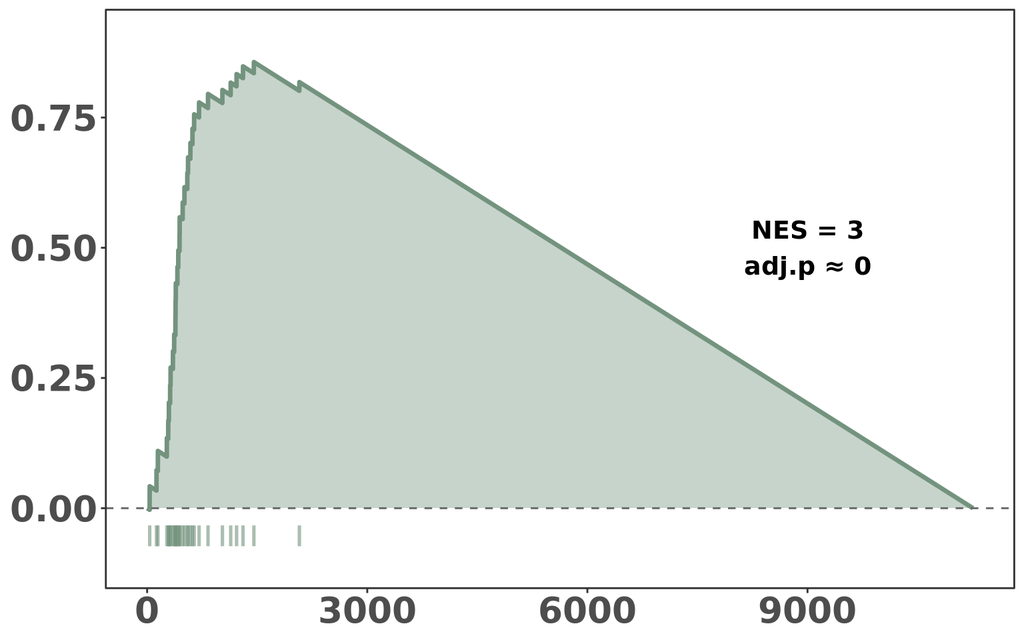

```r
mito.plot.base <- plotEnrichment(custom.gsets[["MitoGenes"]], vectorranks)
curve.data <- mito.plot.base$data

# --- key fix: match the curve's internal descending order ---
ord <- order(vectorranks, decreasing = TRUE)
ranked.names <- names(vectorranks)[ord]
gene.positions <- which(ranked.names %in% custom.gsets[["MitoGenes"]])

rug.top    <- min(curve.data$y) - 0.03
rug.bottom <- rug.top - 0.04

y.min <- rug.bottom - 0.03
y.max <- max(curve.data$y) + 0.05

(mito.plot <- ggplot(curve.data, aes(x = x, y = y)) +
  geom_area(fill = "#73937E", alpha = 0.4) +
  geom_line(color = "#73937E", linewidth = 1.2) +
  geom_hline(yintercept = 0, linetype = "dashed", color = "grey40") +
  geom_segment(data = data.frame(x = gene.positions),
               aes(x = x, xend = x, y = rug.top, yend = rug.bottom),
               color = "#73937E", alpha = 0.6, linewidth = 0.9,
               inherit.aes = FALSE) +
  annotate("text", x = 9000, y = 0.5,
           label = paste0("NES = ", round(mito.res$NES, 2),
                          "\nadj.p ≈ ", round(mito.res$padj, 4)),
           size = 5, family = "Arial MS", fontface = "bold") +
  coord_cartesian(ylim = c(y.min, y.max), clip = "off") +
  theme_bw() +
  theme(text = element_text(size = 25, family = "Arial MS"),
        plot.title = element_text(hjust = 0.5, face = "bold"),
        axis.title = element_blank(),
        axis.text = element_text(face = "bold"),
        panel.grid.minor = element_blank(),
        panel.grid.major = element_blank()))
```

```r
png("~/Projects/StressGranules/SGPAPER/Images/PNG/MitoGSEA_Soma.png", width=7, height=6, units="in", res=300)
mito.plot
dev.off()
```

### For Nuc

```r
# --- Rank genes by t-statistic as usual ---
DEGenes <- DEGenes[order(DEGenes[,4]),]
gseatool <- DEGenes[,4]
gseatool <- as.data.frame(gseatool)
colnames(gseatool)[1] <- "t"
gseatool[,2] <- row.names(DEGenes)
colnames(gseatool)[2] <- "Symbol"
gseatool <- gseatool[,c(2,1)]
vectorranks <- gseatool$t
names(vectorranks) <- gseatool$Symbol

# --- Define MitoGenes as a custom gene set ---
MitoGenes <- fread("~/rnalocate_mito_filt.csv")[[1]]
custom.gsets <- list(MitoGenes = toupper(MitoGenes))

# --- Run fgsea ---
mito.res <- fgsea(pathways = custom.gsets,
                  stats = vectorranks)
```

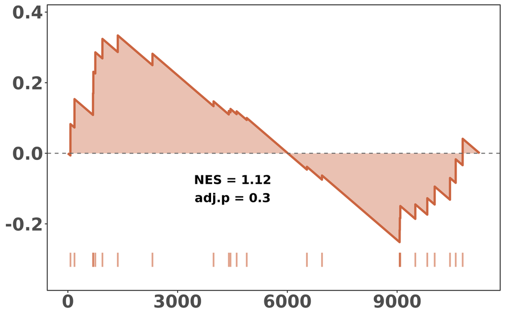

```r
mito.plot.base <- plotEnrichment(custom.gsets[["MitoGenes"]], vectorranks)
curve.data <- mito.plot.base$data

# --- key fix: match the curve's internal descending order ---
ord <- order(vectorranks, decreasing = TRUE)
ranked.names <- names(vectorranks)[ord]
gene.positions <- which(ranked.names %in% custom.gsets[["MitoGenes"]])

rug.top    <- min(curve.data$y) - 0.03
rug.bottom <- rug.top - 0.04

y.min <- rug.bottom - 0.03
y.max <- max(curve.data$y) + 0.05

(mito.plot <- ggplot(curve.data, aes(x = x, y = y)) +
  geom_area(fill = "#CB643F", alpha = 0.4) +
  geom_line(color = "#CB643F", linewidth = 1.2) +
  geom_hline(yintercept = 0, linetype = "dashed", color = "grey40") +
  geom_segment(data = data.frame(x = gene.positions),
               aes(x = x, xend = x, y = rug.top, yend = rug.bottom),
               color = "#CB643F", alpha = 0.6, linewidth = 0.9,
               inherit.aes = FALSE) +
  annotate("text", x = 4500, y = -0.1,
           label = paste0("NES = ", round(mito.res$NES, 2),
                          "\nadj.p = ", round(mito.res$padj, 4)),
           size = 5, family = "Arial MS", fontface = "bold") +
  coord_cartesian(ylim = c(y.min, y.max), clip = "off") +
  theme_bw() +
  theme(text = element_text(size = 25, family = "Arial MS"),
        plot.title = element_text(hjust = 0.5, face = "bold"),
        axis.title = element_blank(),
        axis.text = element_text(face = "bold"),
        panel.grid.minor = element_blank(),
        panel.grid.major = element_blank()))
```

```r
png("~/Projects/StressGranules/SGPAPER/Images/PNG/NucGSEA_Soma.png", width=7, height=6, units="in", res=300)
mito.plot
dev.off()
```

[^1]: Disease Transcriptomics Group, Gulbenkian Institute of Molecular Medicine